# Class 6.3: Building Basic Models

INFO 370A Benjamin Xie & Greg Nelson University of Washington

Adapted from Ch 23, 24 of (R for Data Science)[http://r4ds.had.co.nz], Garrett Grolemund & Hadley Wickham

```r
if(!require(tidyverse)){install.packages("tidyverse"); library(tidyverse)}
if(!require(modelr)){install.packages("modelr"); library(modelr)}
if(!require(splines)){install.packages("splines"); require(splines)}
```

# Interaction Effects

Interactions (continuous & categorical)

`sim3`: categorical predictor (x2) and continuous predictor (x1)

```r
head(sim3)
```

[output not shown]

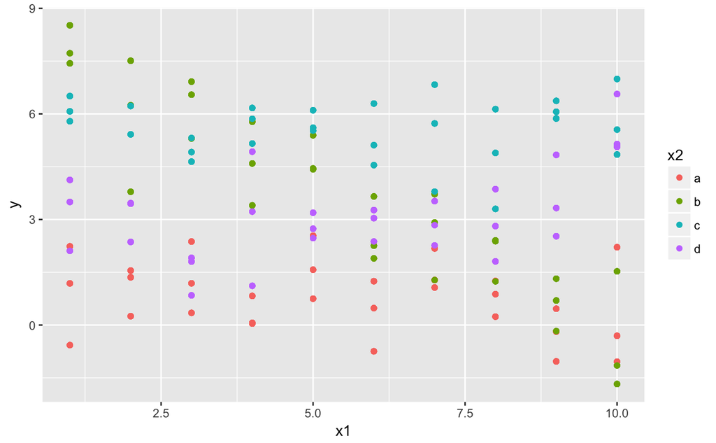

```r
ggplot(sim3, aes(x1, y)) +
  geom_point(aes(color = x2))
```

2 possible models for `sim3` - `+` makes it so model estimates each effect *independent* of all others - `*` model can fit interaction

```r
mod1 <- lm(y ~ x1 + x2,
           data = sim3)
mod2 <- lm(y ~ x1 * x2,
           data = sim3)
# y = a_0 + a_1 * x1 + a_2 * x2 + a_12 * x1 * x2
```

To visualize these models, 2 new tricks: - pass both `x1` and `x2` for `data_grid()` - use `gather_predictions()` to generate predictions from both models simultaneously, adding prediction as a row - complement is `spread_predictions()`, which adds each prediction to a new column

```r
grid <- sim3 %>%
  data_grid(x1, x2) %>%
  gather_predictions(mod1, mod2)
grid
```

| model | x1 | x2 | pred |
| --- | --- | --- | --- |
| mod1 | 1 | a | 1.67492811 |
| mod1 | 1 | b | 4.56273896 |
| mod1 | 1 | c | 6.48066399 |
| mod1 | 1 | d | 4.03451486 |
| mod1 | 2 | a | 1.47819036 |
| mod1 | 2 | b | 4.36600121 |
| mod1 | 2 | c | 6.28392624 |
| mod1 | 2 | d | 3.83777710 |
| mod1 | 3 | a | 1.28145260 |
| mod1 | 3 | b | 4.16926345 |

[output cut: 70 more lines]

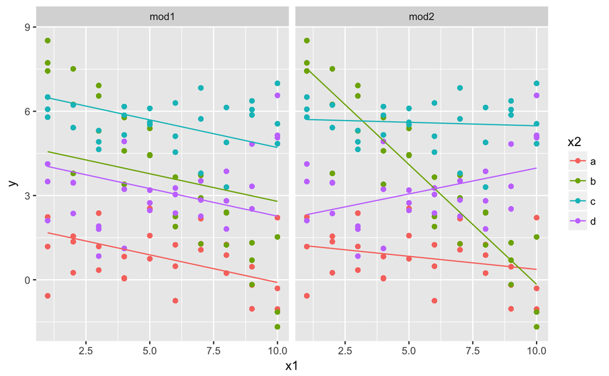

```r
# data_sim3 <- sim3 %>%
#   mutate(
#     mod1 = mad_fit_intercept + mad_fit_slope * data_sim1$x
#   )
ggplot(sim3, aes(x1, y, color = x2)) +
  geom_point() +
  geom_line(data = grid, aes(y = pred)) +
  facet_wrap(~model)
```

Judging model using residuals - residuals in mod1 show pattern (which is bad)

```r
sim3 <- sim3 %>%
  gather_residuals(mod1, mod2)
head(sim3)
```

| model | model | x1 | x2 | rep | y | sd | resid |
| --- | --- | --- | --- | --- | --- | --- | --- |
| mod1 | mod1 | 1 | a | 1 | -0.5707363 | 2 | -2.2456644 |
| mod1 | mod1 | 1 | a | 2 | 1.1841503 | 2 | -0.4907778 |
| mod1 | mod1 | 1 | a | 3 | 2.2373204 | 2 | 0.5623923 |
| mod1 | mod1 | 1 | b | 1 | 7.4366963 | 2 | 2.8739573 |
| mod1 | mod1 | 1 | b | 2 | 8.5182934 | 2 | 3.9555544 |
| mod1 | mod1 | 1 | b | 3 | 7.7239098 | 2 | 3.1611708 |

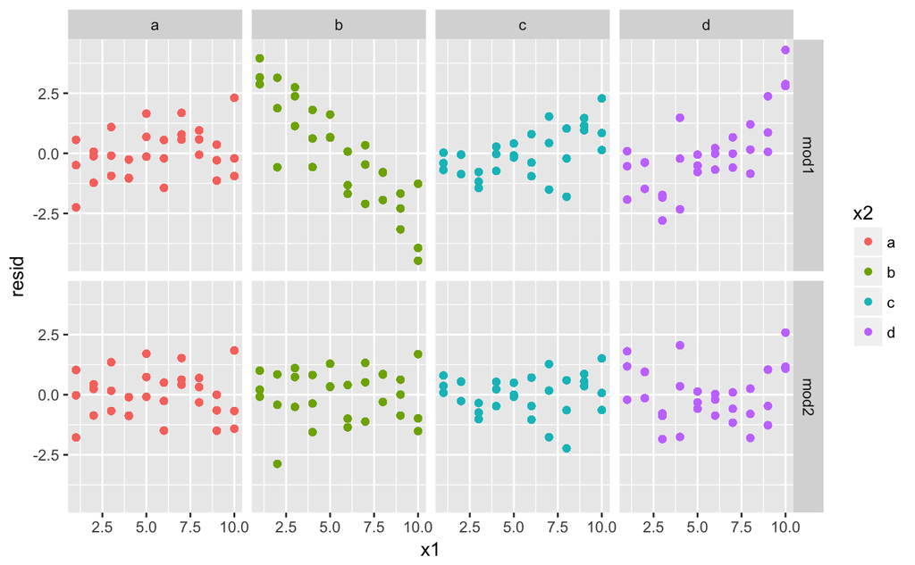

```r
ggplot(sim3, aes(x1, resid, color = x2)) +
  geom_point() +
  facet_grid(model ~ x2)
```

# Looking at non-linear data

Generating some non-linear data

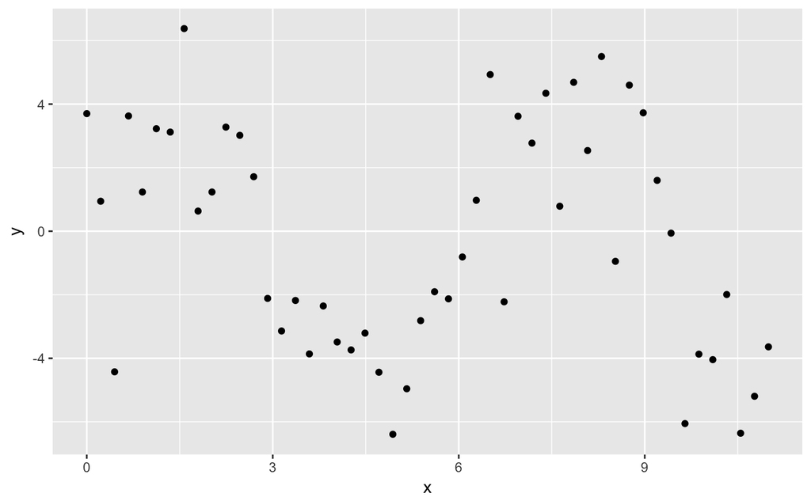

```r
sim5 <- tibble(
  x = seq(0, 3.5 * pi, length = 50),
  y = 4 * sin(x) + rnorm(length(x))*2
)
# plotting random points
ggplot(sim5, aes(x, y)) +
  geom_point()
```

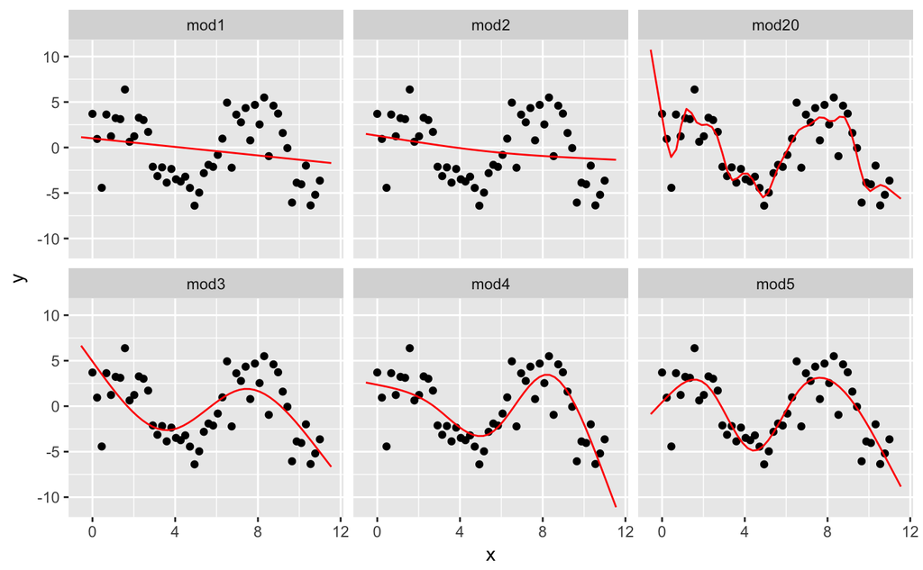

```r
# creating a bunch of "polynomial" models with various degrees of freedom
mod1 <- lm(y ~ ns(x, df=1), data=sim5)
mod2 <- lm(y ~ ns(x, df=2), data=sim5)
mod3 <- lm(y ~ ns(x, df=3), data=sim5)
mod4 <- lm(y ~ ns(x, df=4), data=sim5)
mod5 <- lm(y ~ ns(x, df=5), data=sim5)
mod20 <- lm(y ~ ns(x, df=20), data=sim5)
grid <- sim5 %>%
  data_grid(x = seq_range(x, n= 50, expand = 0.1)) %>%
  gather_predictions(mod1, mod2, mod3, mod4, mod5, mod20, .pred = "y")
# plotting predictions
ggplot(sim5, aes(x,y)) +
  geom_point() +
  geom_line(data = grid, color = "red") +
  facet_wrap(~ model)
```

Looking at residuals

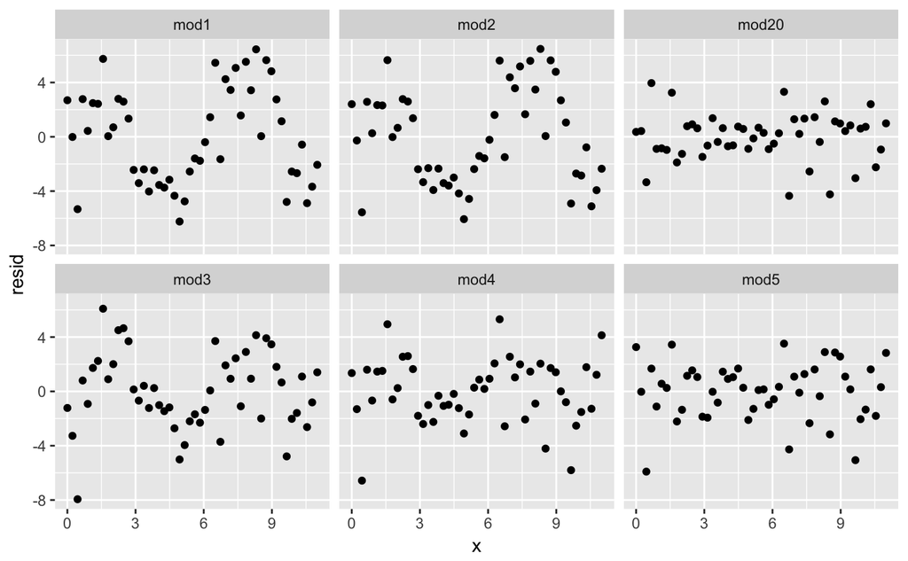

```r
#calculating and plotting residuals
sim5 %>%
  gather_residuals(mod1, mod2, mod3, mod4, mod5, mod20) %>%
  ggplot(aes(x, resid)) +
  geom_point() +
  facet_wrap(~model)
```

# Factors affecting number of flights

Loading packages and data. See help documentation for more on the data.

```r
if(!require(lubridate)){install.packages("lubridate"); library(lubridate)}
if(!require(nycflights13)){install.packages("nycflights13"); require(nycflights13)}
?flights
head(flights)
```

| year | month | day | dep_time | sched_dep_time | dep_delay | arr_time | sched_arr_time | arr_delay | carrier | flight | tailnum | origin | dest | air_time | distance | hour | minute | time_hour |
| --- | --- | --- | --- | --- | --- | --- | --- | --- | --- | --- | --- | --- | --- | --- | --- | --- | --- | --- |
| 2013 | 1 | 1 | 517 | 515 | 2 | 830 | 819 | 11 | UA | 1545 | N14228 | EWR | IAH | 227 | 1400 | 5 | 15 | 2013-01-01 05:00:00 |
| 2013 | 1 | 1 | 533 | 529 | 4 | 850 | 830 | 20 | UA | 1714 | N24211 | LGA | IAH | 227 | 1416 | 5 | 29 | 2013-01-01 05:00:00 |
| 2013 | 1 | 1 | 542 | 540 | 2 | 923 | 850 | 33 | AA | 1141 | N619AA | JFK | MIA | 160 | 1089 | 5 | 40 | 2013-01-01 05:00:00 |
| 2013 | 1 | 1 | 544 | 545 | -1 | 1004 | 1022 | -18 | B6 | 725 | N804JB | JFK | BQN | 183 | 1576 | 5 | 45 | 2013-01-01 05:00:00 |
| 2013 | 1 | 1 | 554 | 600 | -6 | 812 | 837 | -25 | DL | 461 | N668DN | LGA | ATL | 116 | 762 | 6 | 0 | 2013-01-01 06:00:00 |
| 2013 | 1 | 1 | 554 | 558 | -4 | 740 | 728 | 12 | UA | 1696 | N39463 | EWR | ORD | 150 | 719 | 5 | 58 | 2013-01-01 05:00:00 |

Data Cleaning

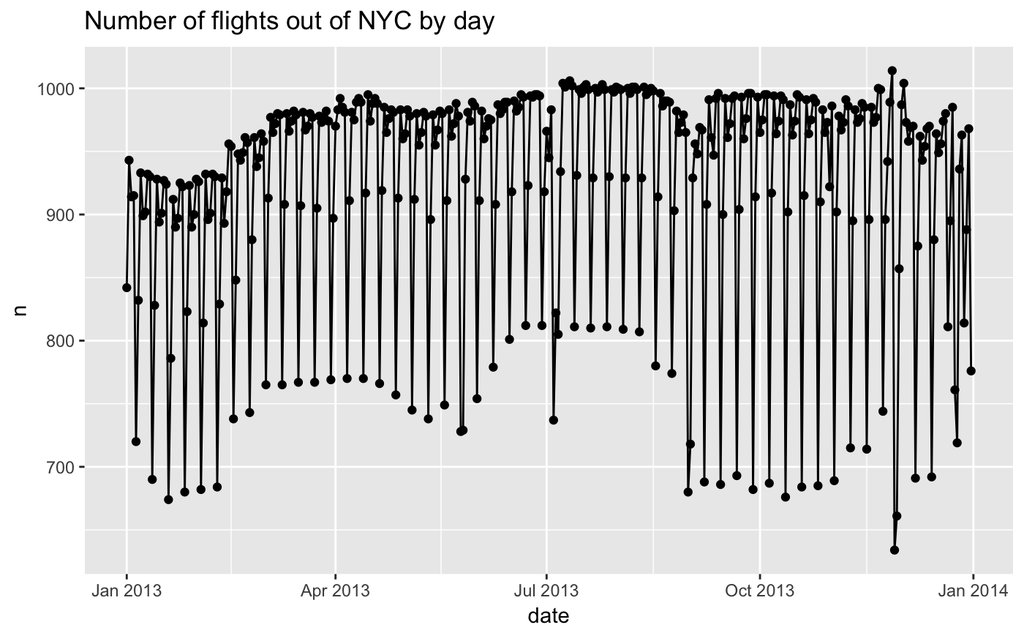

```r
daily <- flights %>%
  mutate(date = make_date(year, month, day)) %>%
  group_by(date) %>%
  summarize(n = n())
# number of flights by day
ggplot(daily, aes(date, n)) +
  geom_line() +
  geom_point() +
  labs(title = "Number of flights out of NYC by day")
```

Controlling by day of week

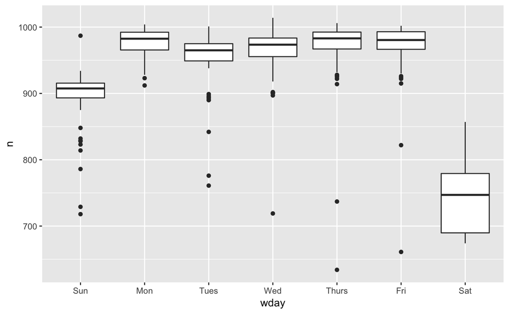

```r
daily <- daily %>%
  mutate(wday = wday(date, label=TRUE))
ggplot(daily, aes(wday, n)) +
  geom_boxplot()
```

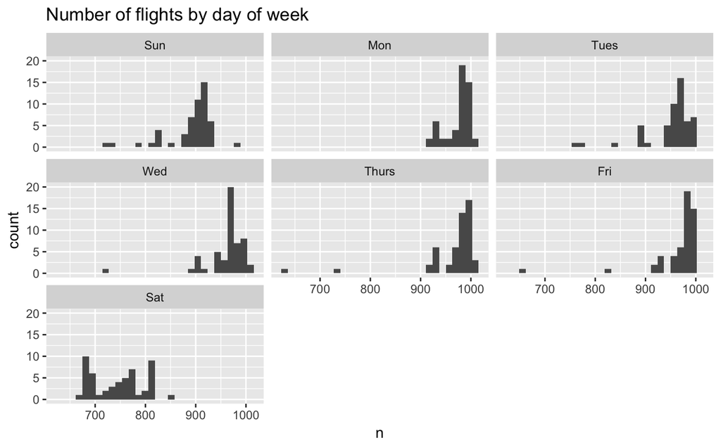

```r
ggplot(daily, aes(n)) +
  geom_histogram() +
  facet_wrap(~wday) +
  labs(title = "Number of flights by day of week")
```

Using model to remove pattern of flights by day of week.

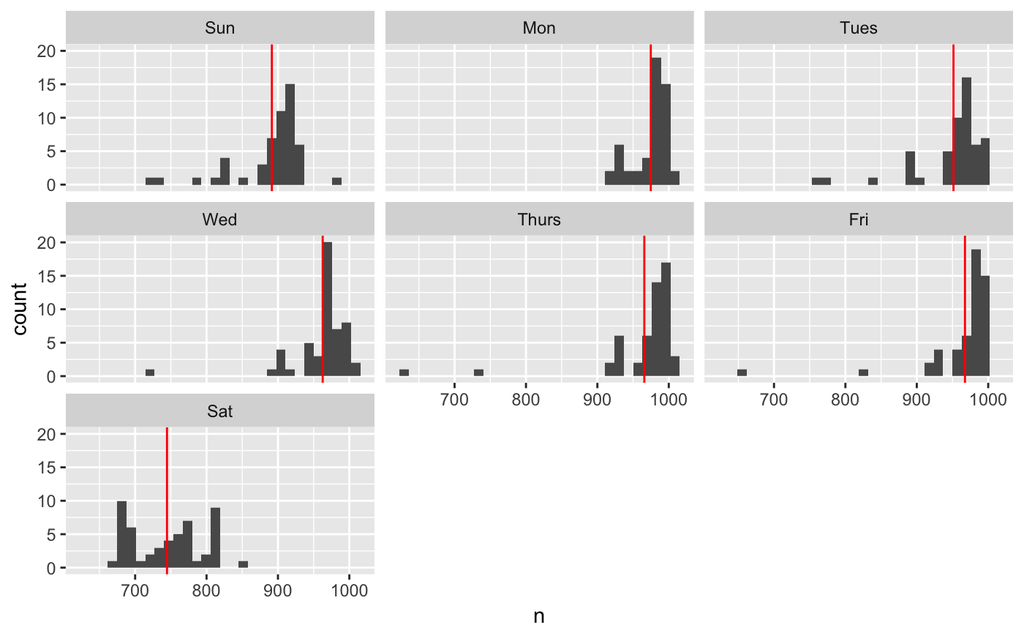

```r
# first fit model and display predictions over original data
mod <- lm(n ~ wday, data = daily)
grid <- daily %>%
  data_grid(wday) %>%
  add_predictions(mod, "n")
# showing prediction
ggplot(daily, aes(n)) +
  geom_histogram() +
  facet_wrap(~wday) +
  geom_vline(data = grid, aes(xintercept = n), color = "red")
```

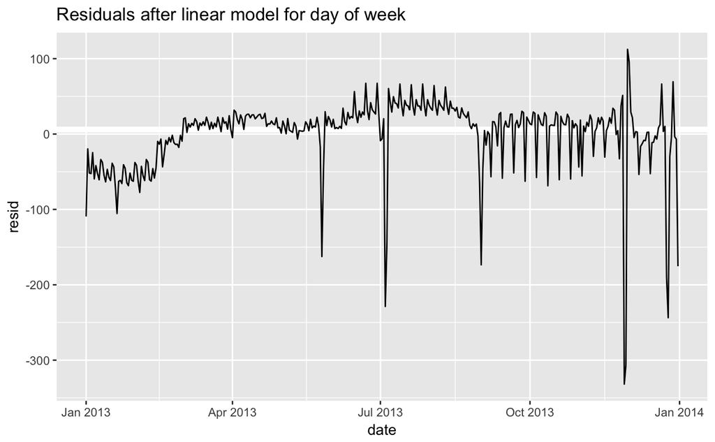

```r
# now compute and visualize residuals
daily <- daily %>%
  add_residuals(mod)
ggplot(daily, aes(date, resid)) +
  geom_ref_line(h=6) +
  geom_line() +
  labs(title = "Residuals after linear model for day of week")
```

```r
daily2 <- daily
# given residuals, maybe we want to remove odd days (Mother's Day, July 4th)
# daily2 <- daily2 %>%
  # filter(resid > -100)
```

Looking at effect of time of year

```r
if(!require(splines)){install.packages("splines"); library(splines)}
if(!require(MASS)){install.packages("MASS"); require(MASS)}
```

Using robust fitting of linear modles (RLM) to create a model with interactions between day of week and time of year

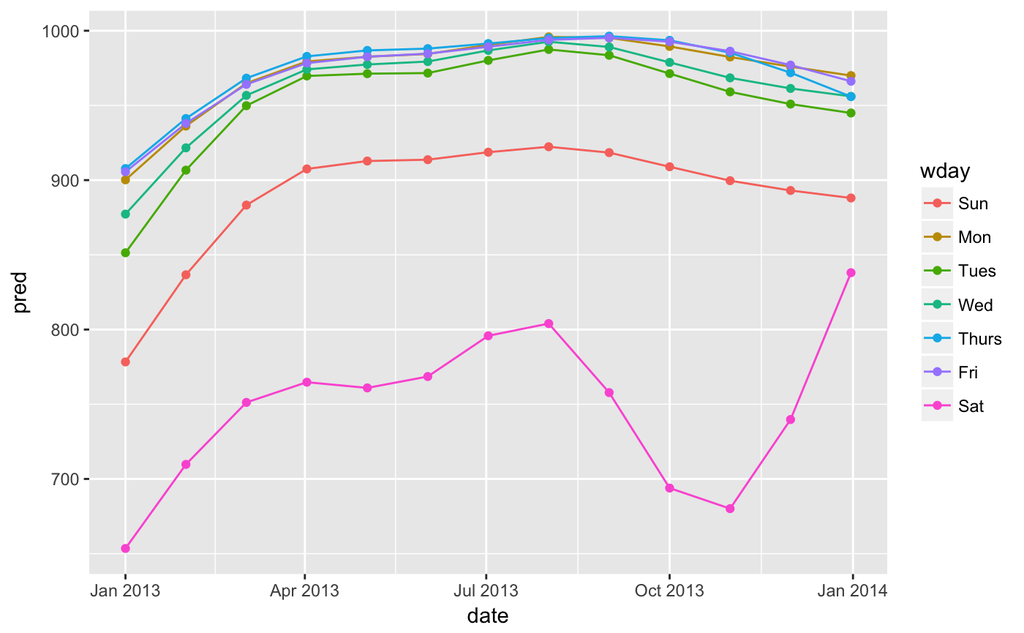

```r
mod <- MASS::rlm(n ~ wday * ns(date, df=5), data = daily)  # degrees of freedom was arbitrary choice
# plot of models
daily2 %>%
  data_grid(wday, date = seq_range(date, n=13)) %>%
  add_predictions(mod) %>%
  ggplot(aes(date, pred, color=wday)) +
    geom_line()+
    geom_point()
```

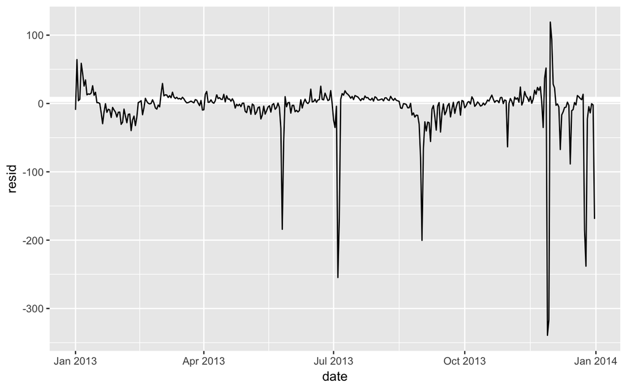

```r
# now compute and visualize residuals
daily2 <- daily2 %>%
  add_residuals(mod)
ggplot(daily2, aes(date, resid)) +
  geom_ref_line(h=6) +
  geom_line()
```